# 비지도학습이란?

##### 지도학습과는 달리 정답(Y)이 없는 데이터를 가지고 학습하는 것이다

##### 비지도학습의 목표는 해당 데이터의 패턴, 특성 및 구조를 스스로 파악하여 이를 통해 데이터가 어떻게 구성되었는지 새로운 규칙성을 알아내는 과정

비지도학습은 크게 군집분석과 차원축소로 나눌 수 있다

### Dimension Reduction - 차원축소

##### 차원 축소는 매우 많은 피처로 구성된 다차원 데이터 세트의 차원을 축소해 새로운 차원의 데이터 세트를 생성하는 것이다.

##### 일반적으로 차원이 증가할수록 데이터 간의 거리가 기하급수적으로 증가하기 때문에 희소한 구조를 가지게 되고 모델의 예측 신뢰도가 떨어지게 된다.

##### 이는 곧 모델 학습의 성능을 저하시키게 되고, 이러한 현상을 '차원의 저주'라고도 한다.

##### 차원 축소를 할 경우 학습 데이터의 크기가 줄어들어서 학습에 필요한 처리 능력도 줄일 수 있다.

### pca

##### pca는 비지도학습에서 대표적인 차원 축소 기법으로 고차원의 데이터를 저차원의 데이터로 변환하는 기법이다.

##### 차원을 축소하는 과정에서, 원래 데이터의 정보를 최대한 유지하는 것이 목표이다.

##### 다시말해 차원을 축소하면서 발생하는 데이터의 손실을 최소화 하는것이 핵심인데

##### 이를 위해 데이터를 축에 사영했을 때 가장 높은 분산을 가지는 데이터의 축을 찾아 그 축으로 차원을 축소한다.

##### 사영했을 때 분산이 크다는 것은 원래 데이터의 분포를 잘 설명할 수 있다는 것을 뜻하고 정보의 손실을 최소화 할 수 있다는 것을 뜻한다.

##### 앞에서 설명한 말을 아래의 그림으로 보자.

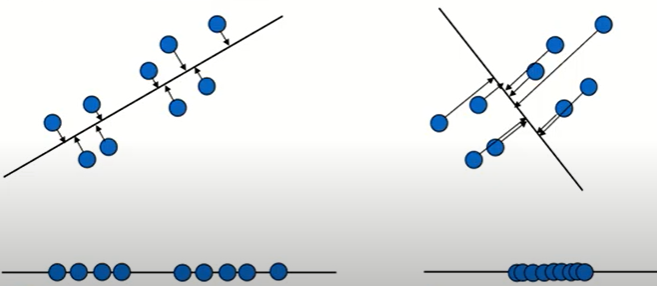

```python
from IPython.display import Image
image_path = 'C:/Users/jaemi/OneDrive/Desktop/비지도학습/pca/img1.png'
Image(filename=image_path, width=700)
```

##### 위 그림에서 한눈에 봐도 데이터를 좌측 축에 사영시키는 것이 데이터의 원래 분포를 잘 설명한다고 볼 수 있다.

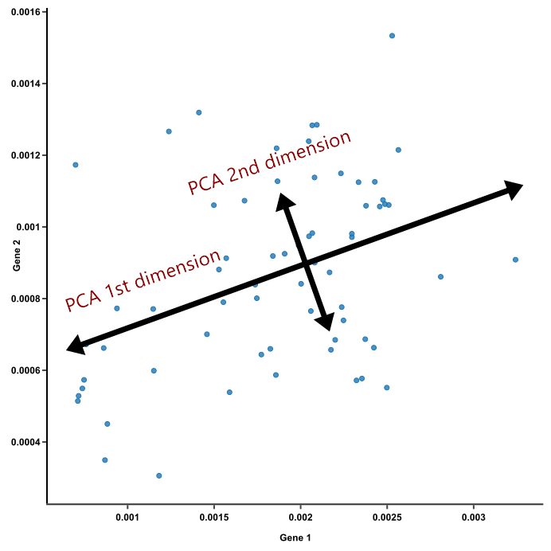

```python
from IPython.display import Image
image_path = 'C:/Users/jaemi/OneDrive/Desktop/비지도학습/pca/img2.png'
Image(filename=image_path, width=500)
```

##### 위 그림은 원본 데이터를 pca를 통해 차원축소하는 과정에서 생성되는 2개의 축을 보여준다.

##### 제일 먼저 가장 큰 분산을 기반으로 첫 번째 축을 생성하고,

##### 두 번째 축은 이 벡터 축에 직각이 되는 벡터를 축으로 한다.

##### 세 번째 축은 다시 두 번째 축과 직각이 되는 벡터를 축으로 설정하는 방식으로 축을 생성한다.

##### 이렇게 생성된 벡터 축에 원본 데이터를 투영하면 벡터 축의 개수만큼의 차원으로 원본 데이터가 차원 축소된다.

### pca 파이썬 실습

#### 1. 데이터 준비

##### pca도 clustering에서 사용했던 데이터인 iris 데이터를 사용한다.

##### 비지도학습인 pca이기에 종속변수를 제외하고 독립변수만으로 데이터프레임을 구성한다.

```python
#실습 데이터 Load & Dataframe 변환
from sklearn import datasets
import pandas as pd

iris = datasets.load_iris()
y = pd.DataFrame(iris.target)
y.columns=['labels']
data = pd.DataFrame(iris.data)
data.columns=['Sepal length','Sepal width','Petal length','Petal width']
data = pd.concat([data,y],axis=1)

data.head()
```

|  | Sepal length | Sepal width | Petal length | Petal width | labels |
| --- | --- | --- | --- | --- | --- |
| 0 | 5.1 | 3.5 | 1.4 | 0.2 | 0 |
| 1 | 4.9 | 3.0 | 1.4 | 0.2 | 0 |
| 2 | 4.7 | 3.2 | 1.3 | 0.2 | 0 |
| 3 | 4.6 | 3.1 | 1.5 | 0.2 | 0 |
| 4 | 5.0 | 3.6 | 1.4 | 0.2 | 0 |

```python
df = data[ ['Sepal length','Sepal width','Petal length','Petal width']]
df.head()
```

|  | Sepal length | Sepal width | Petal length | Petal width |
| --- | --- | --- | --- | --- |
| 0 | 5.1 | 3.5 | 1.4 | 0.2 |
| 1 | 4.9 | 3.0 | 1.4 | 0.2 |
| 2 | 4.7 | 3.2 | 1.3 | 0.2 |
| 3 | 4.6 | 3.1 | 1.5 | 0.2 |
| 4 | 5.0 | 3.6 | 1.4 | 0.2 |

#### 2. pca적용

##### df데이터를 pca를 통해 차원축소를 진행한다.

##### 4차원의 데이터를 몇차원으로 축소할지는 정답이 없다. 이번 실습에서는 시각화를 용이하게 하기위해 임의로 2차원으로 축소시키겠다.

##### parameter로 n_components=2(몇차원으로 축소시킬지) 지정해 주었다.

```python
from sklearn.preprocessing import StandardScaler
from sklearn.decomposition import PCA

#2차원으로 차원 축소
pca=PCA(n_components=2)
pca.fit(df)
df_pca=pca.transform(df)

pca_columns=['pca_component_1','pca_component_2']
df_pca=pd.DataFrame(df_pca,columns=pca_columns)
df_pca.head()
```

|  | pca_component_1 | pca_component_2 |
| --- | --- | --- |
| 0 | -2.684126 | 0.319397 |
| 1 | -2.714142 | -0.177001 |
| 2 | -2.888991 | -0.144949 |
| 3 | -2.745343 | -0.318299 |
| 4 | -2.728717 | 0.326755 |

##### PCA 주성분 별로 원본 데이터의 주성분을 얼마나 반영하는지 아래의 코드로 알아보자.

```python
pca.explained_variance_ratio_
```

```
array([0.92461872, 0.05306648])
```

##### 첫 번째 주성분이 약 92.46%

##### 두 번째 주성분이 약 5.3%로

##### 두 주성분이 원본 데이터를 약 97.76%를 설명할 수 있는 것을 확인할 수 있다.

#### 3. 차원축소된 데이터로 군집분석에 활용

##### 이전에 iris데이터를 k-means와 dbscan 알고리즘으로 군집분석 후 시각화를 했을때는 4차원의 데이터를 2차원 평면에 시각화를 했으므로 어려움이 있었다.

##### pca를 통해 2차원으로 축소 시켰으니 이 데이터로 k-means를 진행시켜보자.

##### 최적의 k를 찾는 과정을 생략하고 임의로 k=3을 설정해서 군집분석을 진행하였다.

```python
from sklearn.cluster import KMeans
model = KMeans(n_clusters = 3, random_state=7)
model.fit(df_pca)

new_labels =pd.DataFrame(model.labels_)
new_labels.columns=['cluster']

r = pd.concat([df_pca,new_labels],axis=1)
```

#### 4. 결과 시각화

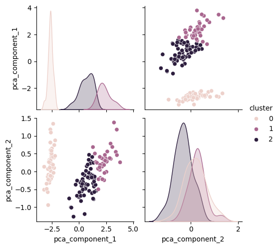

```python
#pairplot with Seaborn
sns.pairplot(r,hue='cluster')
plt.show()
```